# Workaway - exploring recent travelling trend

by Jakub Fiutkowski

Workaway is an online platform connecting people from all over the world - the ones who want to decrease travel expenses with the others who need some help around the house or in their business activities. I’ve been using the platform heavily in the past months and I’m wondering if I could have improved my experience somehow. Host rating prediction based on profile description would be performed and multiple rating statistics assessed.

## Data Exploration

Glossary to make reading easier:

1. Workaway - name of work&travel portal
2. Host - person who accepts travellers in their house
3. workawayer/guest - person who is travelling

All records are related to Host profiles were downloaded from Workaway portal via *Selenium*. Variables present are the following:

```
## Rows: 26,776
## Columns: 31
## $ title                       <chr> "Artistic helpers to create a friendly env~
## $ country_host                <chr> "Albania", "Albania", "Albania", "Albania"~
## $ host_rating                 <int> 80, 80, 100, 100, 80, 100, 85, 80, 100, 10~
## $ ww_comm                     <chr> "['(Very good )', '(Excellent )']", "['(Ex~
## $ h_comm                      <chr> NA, "['(Excellent )', '(Excellent )', '(Ex~
## $ feedback_no                 <int> 2, 14, 54, 9, 8, 45, 3, 127, 32, 10, 3, 6,~
## $ last_activity               <date> 2022-09-30, 2022-09-30, 2022-09-30, 2022-~
## $ reply_rate                  <dbl> 71.6, 50.5, 96.8, 89.7, 68.2, 90.2, 97.7, ~
## $ average_reply_time          <int> 4, 7, 2, 4, 6, 6, 11, NA, 10, 6, 17, 3, 5,~
## $ favourited                  <int> 205, 996, 1194, 79, 234, 624, 144, 1697, 1~
## $ min_stay                    <chr> " Min stay requested: at least 3 weeks", "~
## $ description                 <chr> "This is a brand new hostel located near t~
## $ types_of_help               <chr> "Art Projects\nLanguage practice\nHelp wit~
```

[output cut: 18 more lines]

We have thousands of records meaning that 27k people are willing to accept a stranger in their house offering food and accommodation in exchange for a few hours of work. The data is a mixture of all, with a majority of **character** type, so it would certainly require transforamtion and text analysis. Dataset is mostly complete, however several variables are missing in ~50%.

### Geography

Let’s see first how many countries in total participate?

```
## # A tibble: 156 x 2
## # Groups:   country_host [156]
##    country_host      n
##    <chr>         <int>
##  1 France         2478
##  2 Spain          2253
##  3 Italy          1859
##  4 Canada         1310
##  5 Australia      1274
##  6 New Zealand     878
##  7 Germany         861
##  8 United States   813
##  9 Portugal        798
## 10 Ireland         740
## # ... with 146 more rows
```

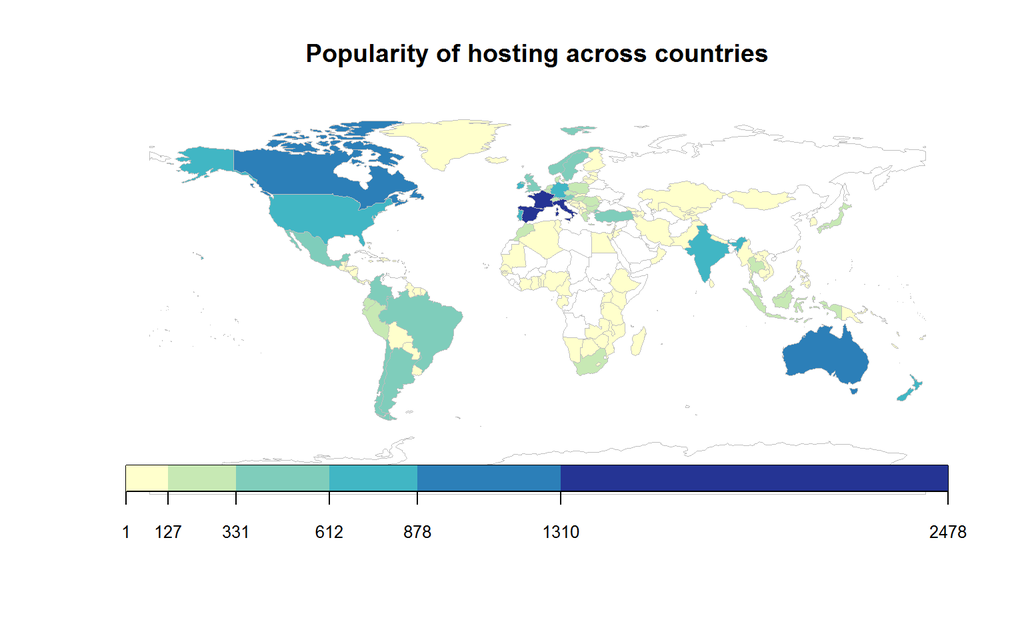

Africa is the least popular, with low or 0 observations (hosts offering work) among its countries. On the other hand the most blueish part is Europe, indicating it might be the best part of world to start your workawayer adventure - luckily that’s what I did! Interestingly, we can’t see any data in Russia which is the largest country on our globe… After digging it into we can discover that it have been banned from portal search engine due to either security or political reasons.

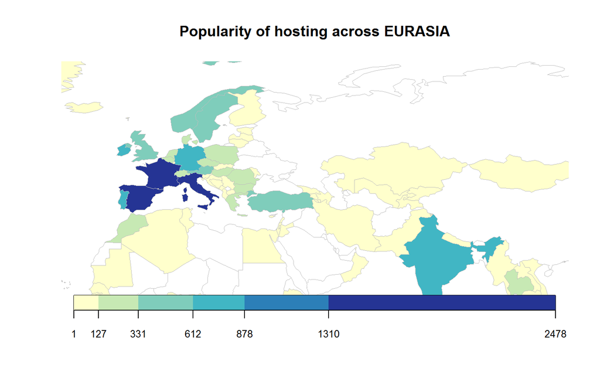

Another glimpse on Eurasia shows that one can choose from 100+ offers only in European countries - furthermore basically all continent is covered giving potential traveler enormous cultural opportunities!

For the rest of EDA we focus solely on Europe as it covers almost 50% of all observations.

## Working hours

Let’s look at *hours expected* variable quite important to know beforehand how long a person is supposed to work on an average basis. This was unfortunately designed as a textbox input by portal, thus required some heavy transformations for visualization.

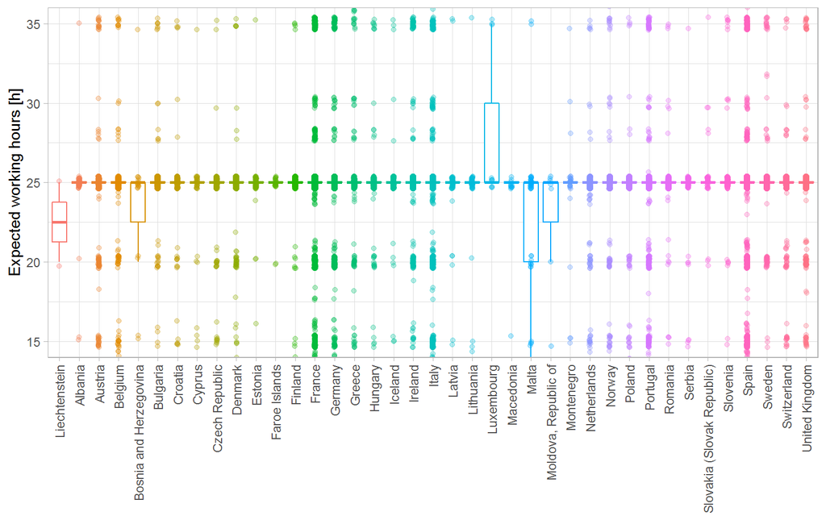

The distributions are clearly non-normal. Observations are concentrated around multiple of 5-hour intervals, with heaviest concentration in 25 hours vicinity. It means most of the hosts stick to the standard Workaway policy “5 hours a day, 5 days a week”.

We can exclude countries with low observations for better visualization:

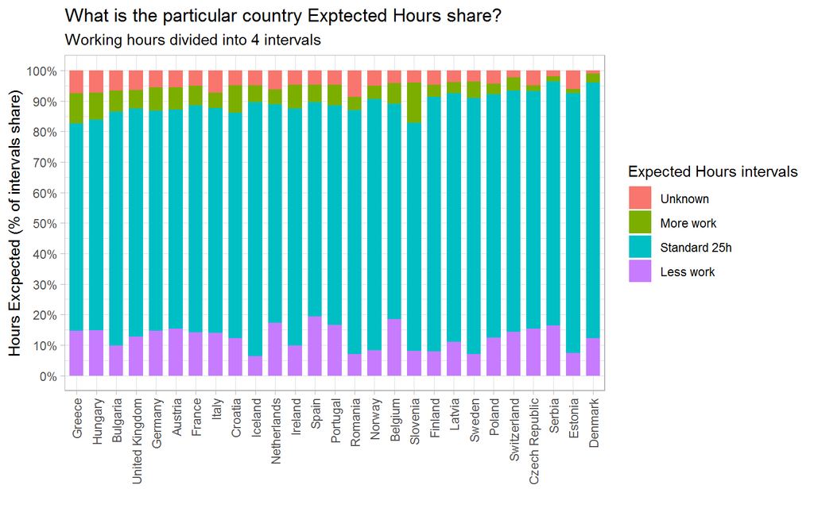

After dividing working hours into the most popular 4 categories, 25 hours domination is obvious. Some hosts don’t indicate precisely what are the working hours, so they write i.e. “8 hours” leaving some space for interpretation. We classify these cases as **UNKNOWN**, and keep variable in categorical form for prediction purposes.

### Rating by Country

How are European countries assesed on average?

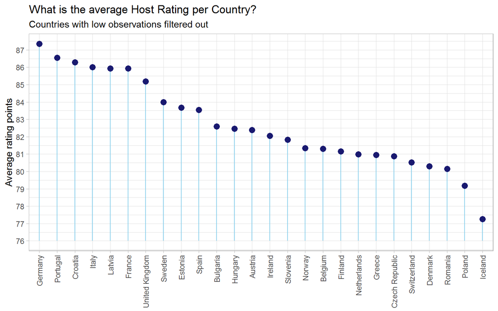

There is a clear trend so *country* will also be later used as independent variable, with low-observations countries pulled together.

## Hosts quality metrics

The useful tool for choosing your host partner is choosing one of the rating metrics. These are as follows:

1. User feedback - it allows assessing a host by 3 separate categories (profile accuracy, communication, and cultural exchange) 1 to 5 stars each, and every category is displayed separately and averaged on all feedbacks per host. This is the most informative metric, however it’s also a newer one, so it’s unavailable on some profiles.
2. Host rating - it is a formula proposed by the portal, which supposedly takes into account measures like reply rate, average reply time, host activity on site and… “of course user feedbacks”.

Let’s pull the three detailed user-feedback metrics into 1 *feedback total*, and compare it with website formula *host rating*.

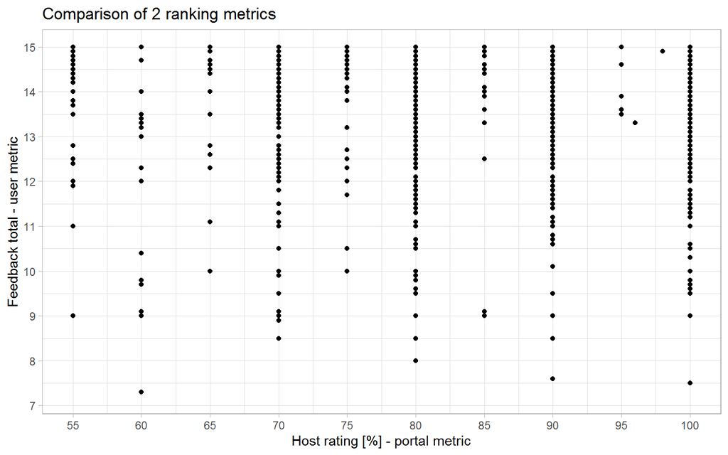

That’s really interesting!

1. Host rating metric is more like categorical than continuous measure, which is strange as it supposedly is based on numeric-type inputs
2. We have total mixture of different observations:
- 100% *host rating* can have minimal *feedback total* rating
- full scale *feedback total* (15.0), is present across all *host rating* levels

### Find words related to feedback total

We divide *feedback total* into 4 intervals.

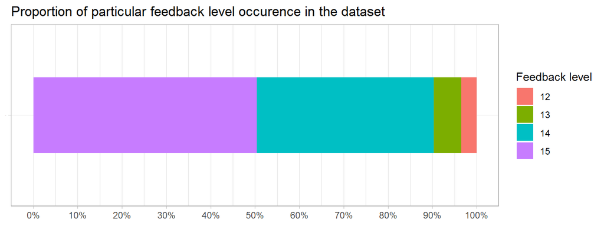

Reality of *feedback total* scale <0; 15> is that among non-missing data, 90% values fall between <14;15> range.

We will take the top 200 words from tokenized *accommodation*, filter out *stop words* in all popular languages (English, French, Spanish, German, Polish), as well as plurals (English only as is the most popular). Then create all pairs of word vs feedback level.

```
## # A tibble: 800 x 5
##    word          feedback_total     n  total proportion
##    <chr>                  <dbl> <int>  <int>      <dbl>
##  1 accommodate               12     9  10660   0.000844
##  2 accommodate               13    30  20793   0.00144
##  3 accommodate               14   161 140395   0.00115
##  4 accommodate               15   183 159676   0.00115
##  5 accommodation             12    79  10660   0.00741
##  6 accommodation             13   115  20793   0.00553
##  7 accommodation             14   790 140395   0.00563
##  8 accommodation             15   813 159676   0.00509
##  9 accomodation              12    20  10660   0.00188
## 10 accomodation              13    16  20793   0.000769
## # ... with 790 more rows
```

We proceed with predicting occurrence of words in particular level **as word count out of total counts in level** via GLM model.

```
## # A tibble: 200 x 7
##    word     data             term           estimate std.error statistic p.value
##    <chr>    <list>           <chr>             <dbl>     <dbl>     <dbl>   <dbl>
##  1 queen    <tibble [4 x 4]> feedback_total    0.499    0.0906      5.51 6.89e-6
##  2 spare    <tibble [4 x 4]> feedback_total    0.490    0.105       4.67 5.78e-4
##  3 size     <tibble [4 x 4]> feedback_total    0.441    0.0958      4.60 7.89e-4
##  4 happy    <tibble [4 x 4]> feedback_total    0.371    0.0700      5.30 2.29e-5
##  5 lovely   <tibble [4 x 4]> feedback_total    0.322    0.103       3.13 2.89e-1
##  6 join     <tibble [4 x 4]> feedback_total    0.311    0.0934      3.33 1.50e-1
##  7 love     <tibble [4 x 4]> feedback_total    0.309    0.0719      4.30 3.19e-3
##  8 children <tibble [4 x 4]> feedback_total    0.306    0.105       2.92 5.48e-1
##  9 maison   <tibble [4 x 4]> feedback_total    0.302    0.0941      3.21 2.26e-1
## 10 bath     <tibble [4 x 4]> feedback_total    0.290    0.0808      3.59 5.76e-2
## # ... with 190 more rows
```

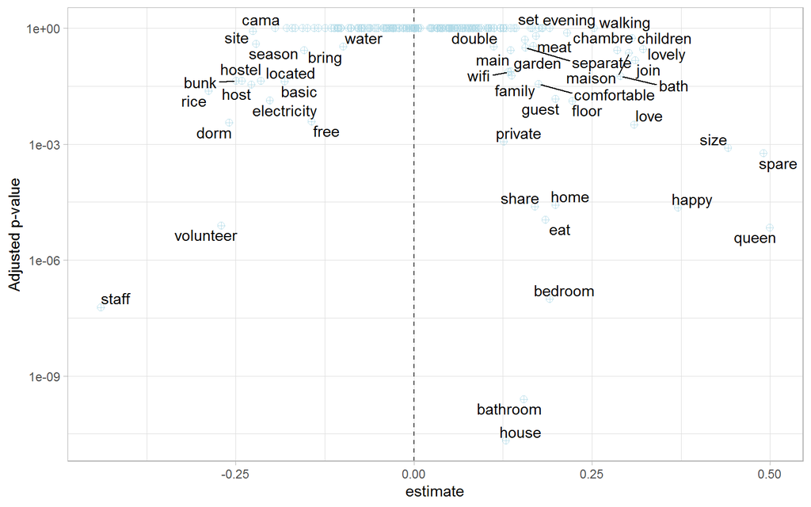

Volcano plot shows how each word’s effect size relates to p-value.

1. High positive estimates are: **happy, eat, love, size, queen, spare, private.**
2. Low estimate of significant words are: **basic, bunk, electricity, hostel, rice, staff, volunteer.**

Filtering TOP low and high estimates below 0.05 p-value level, we visualize it against pre-defined *feedback total* levels:

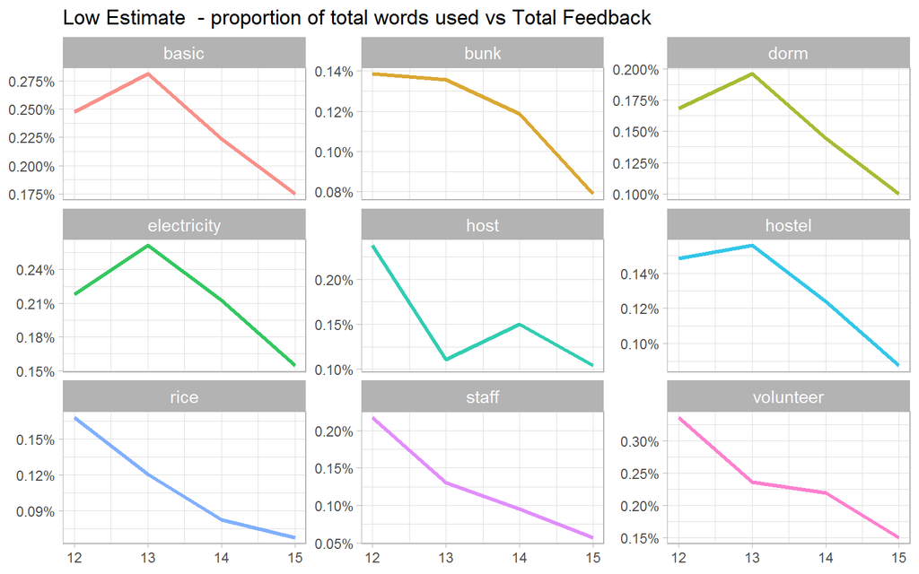

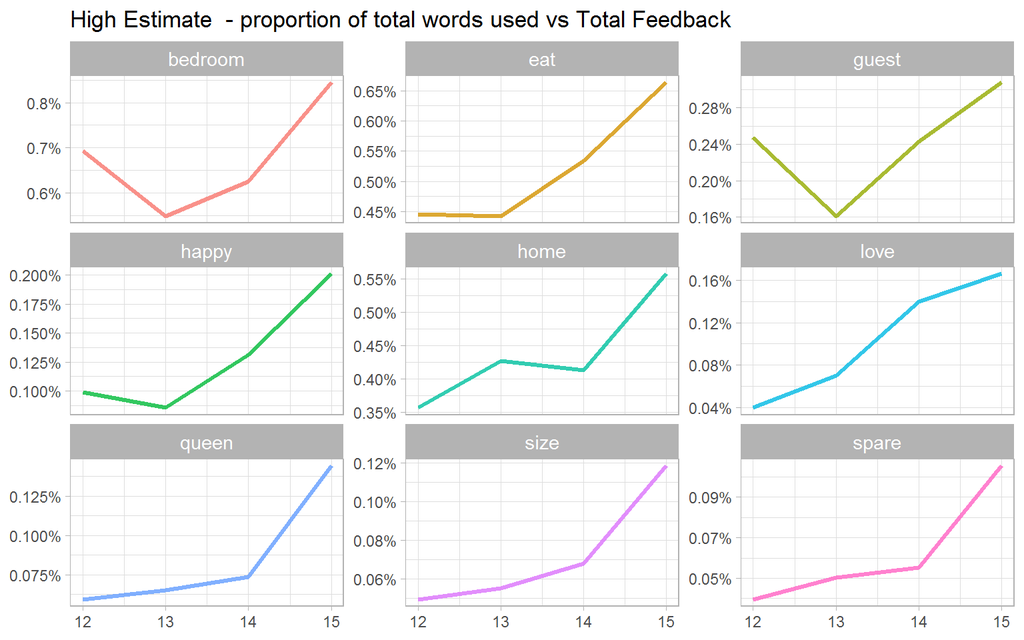

Some of the interesting cases:

1. **electricity** trending downwards - that’s because if there is electricity everywhere in the place hosts don’t mention it. On the other hand, if potential workawayer is going to sleep in a tent or campervan, where electricity is limited, host wants to point it out
2. **rice, basic** in low estimates - food is not always included. Sometimes host can cook for you, and the other times you are provided with ingredients to cook for yourself - it can be i.e. “**rice**, or **basic** ingredients”. **Basic** can also relate to comfort of accommodation in general
3. **eat, love** in TOP WORDS - these words may occur in description where host writes about cooking delicious food for guest who will **eat** it and **love** it. **Love** can relate also to comfort of accommodation place and is less likely to be used if guest sleeps in a cold tent or large dormitory with 15 other people

These tokens would be used for prediction of rating metrics. Similar process is performed for the following independent variables:

- description
- help
- what else and cultural exchange (joined together)

## Modelling ‘Host Rating’ metric

Let’s build a regression model which would predict the *host rating* based on the basic numeric variables plus word tokens obtained from GLM models.

Evaluation would be based on RMSE and observations from all countries included. The baseline score for performance comparison is:

```r
sd(sd_calc$host_rating)
```

```
## [1] 13.87971
```

First we perform spot checking using mixture of linear, nonlinear and ensemble models.

10 different models were tuned via small grid latin hypercube.

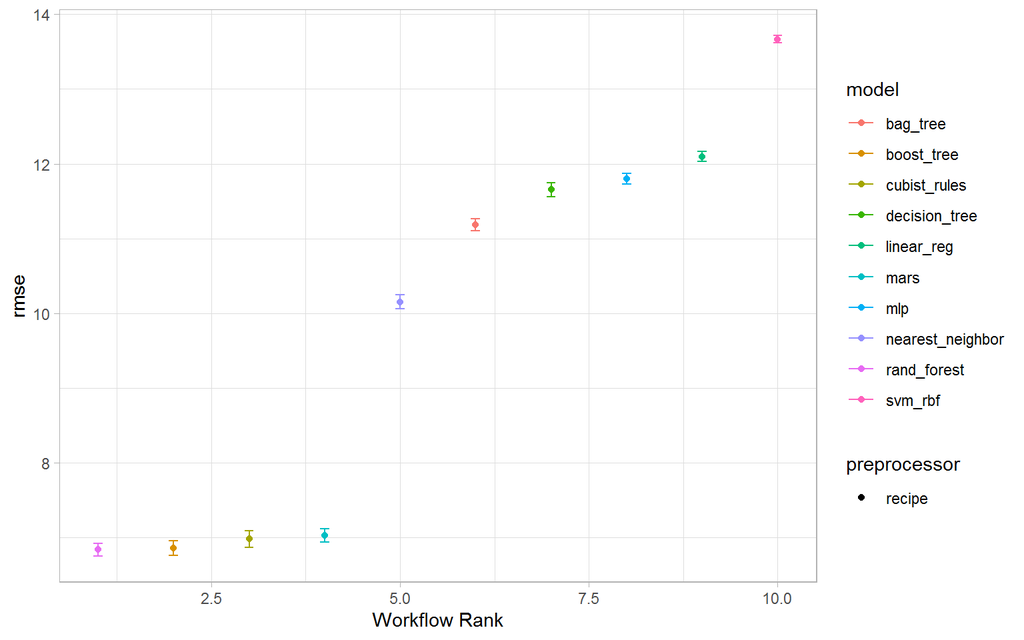

As we see apart from MultivariateAdaptiveRegressionSplines, RandomForest, XGBoost and Cubist, the rest of the models underperformed, therefore would be excluded from further evaluation.

We also look at variable importance measures of 2 of the well-performing models - XGboost and Cubist. DALEXetra package was used for this purpose.

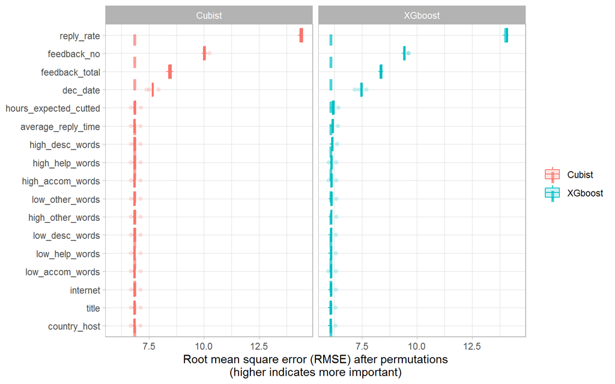

Conformity between models regarding predictors importance means that these ones are indeed influenatial.

However only a few of predictors really matters, with *reply rate* being in the lead:

- reply rate - percentage of messages replied by host
- feedback no - number of feedbacks
- feedback total - summarized user rating (communication, cultural exchange, accuracy of profile)
- dec date - host’s last time of activity on the portal

It might be beneficial to look at this stage again at completeness of data:

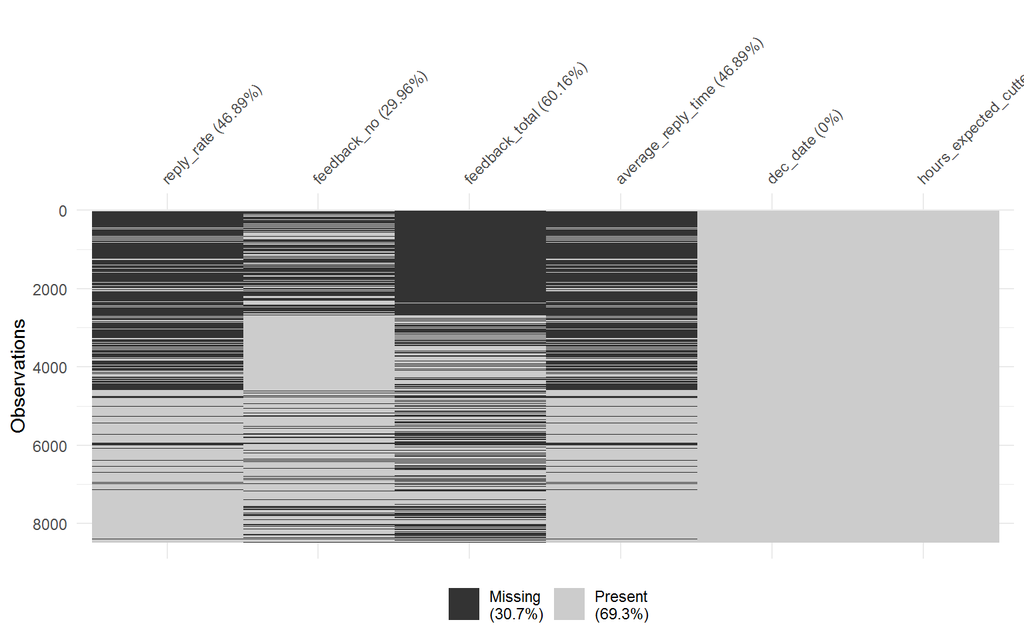

- 31% data missing
- it’s common that if 1 value is missing, 2 or even 3 other variables are missing as well
- *reply rate* is missing in 47% total, and it’s the most meaningful of all!

Let’s look directly on the relationship *reply rate* ‘missingness’ vs. dependent variable in the training set:

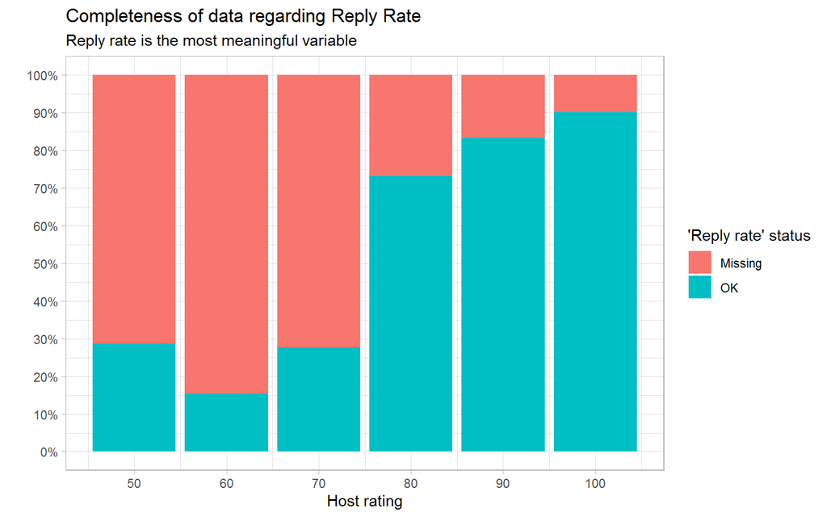

That’s a truly disappointing discovery! *Reply rate* is so hard-connected to our dependent variable, but it’s also a missing one. After trying several attempts of unsuccessful imputation with different methods I decided to go back to Workaway portal… And it occurred there might be a **third metric**! Just near every user/host comment there is 1 to 5 stars scale (initially I thought this is part of *feedback total*). **We put it into the dataset then!**

New variables are:

- h_count - number of comments left by HOST
- h_avg - averaged star-rating of above
- ww_count - number of WORKAWAY comments left from workawayer for a host
- ww_avg - averaged star-rating of above
- favourited - how many workawayers clicked ‘a like button’

Double-check correlation with previous variables:

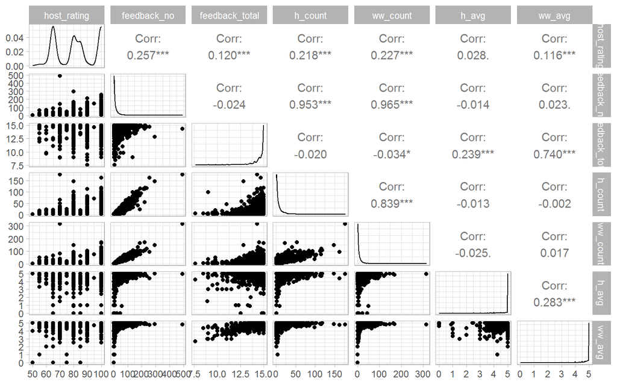

Now we perform a thorough tune-search on one of the best performing models from earlier spot-checking - XGBoost. This time with new variables added.

### Host Rating Evaluation

```
## # A tibble: 2 x 10
##   trees min_n tree_depth learn_rate .metric .estimator  mean     n std_err
##   <int> <int>      <int>      <dbl> <chr>   <chr>      <dbl> <int>   <dbl>
## 1   472    23         15    0.00665 rmse    standard   5.84      5 0.0624
## 2   472    23         15    0.00665 rsq     standard   0.893     5 0.00257
## # ... with 1 more variable: .config <chr>
```

Last fit on test set to confirm we are not overfitting:

```
## # A tibble: 2 x 4
##   .metric .estimator .estimate .config
##   <chr>   <chr>          <dbl> <chr>
## 1 rmse    standard       5.89  Preprocessor1_Model1
## 2 rsq     standard       0.887 Preprocessor1_Model1
```

XGboost model in conjunction with parsnip package has functionality of calculating importance scores directly from fitted model, let’s use it:

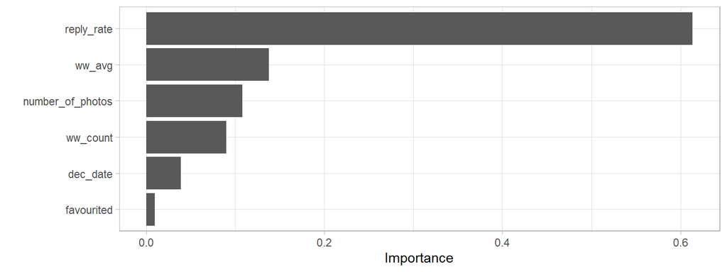

Difference between resamples and testing set is minimal, both in terms on RMSE and R-squared.

Again we have *reply rate* on the first position with huge importance, however this time on the second place jumped *ww_avg* (average score left for the host), which was exchanged for the previously used *feedback_total*.

## Modelling ‘Star’ metric

Let’s build another model, one which would predict the *ww_avg* - Star rating. As we saw earlier the *feedback total* score is extremely imbalanced, so the problem concerns *ww_avg* as well, which is just a subgroup of the former. So there are mostly “5-es” in the dataset - we make a cut-off point at exactly 5.0 and treat values equal 5 as **positives** and **negative** otherwise. This way we can pick “the best of the best” hosts from the Workaway portal using classification methods.

We use again the full variable set in the beginning. Additionally new variables are created:

1. total number of sentences in summarized text fields (description + accommodation + help + cultural exchange + what else)
2. emotion scores like joy/fear/trust/disgust etc. calculated on text

Similarly we tune a bunch of models with space-filling design:

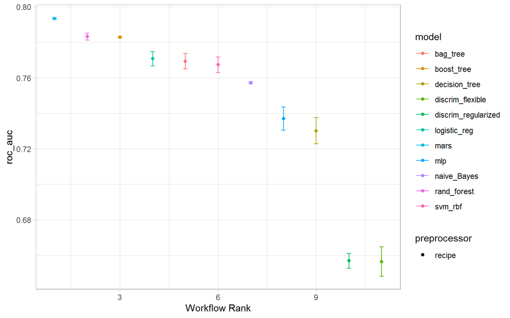

### ‘Star’ Rating Evaluation

This time MARS model was chosen for final assessment as a best one.

Confusion matrix:

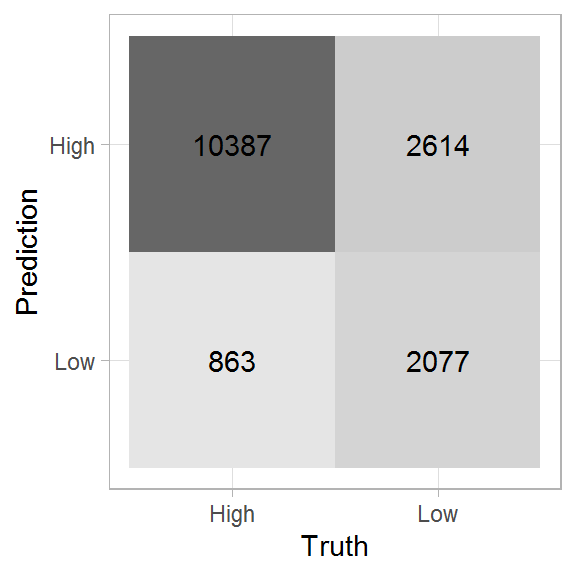

Variable importance scores:

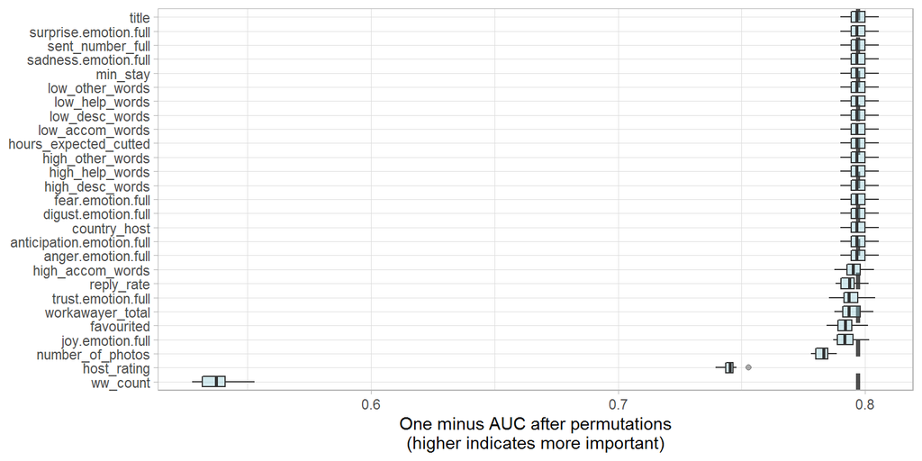

We see that most of the variability in the model is explained by number of comments. In addition type I error is really large, and this is exactly the error we want to minimize (create a model which would safely indicate the 5-star rating host). Because of imbalanced data we would build a model again using downsampling this time.

Confusion matrix on model **with downsampling**:

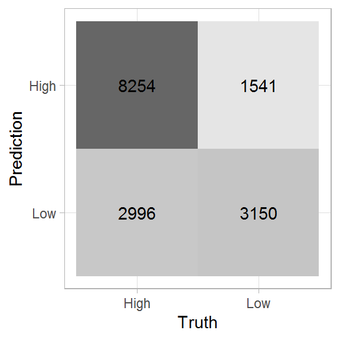

Resample statistics of the model:

```
## # A tibble: 4 x 5
##   .config              model .metric    mean std_err
##   <chr>                <chr> <chr>     <dbl>   <dbl>
## 1 Preprocessor1_Model1 mars  accuracy  0.715 0.00506
## 2 Preprocessor1_Model1 mars  precision 0.843 0.00348
## 3 Preprocessor1_Model1 mars  roc_auc   0.761 0.00564
## 4 Preprocessor1_Model1 mars  sens      0.734 0.00465
```

Last fit on test set:

```
## # A tibble: 2 x 4
##   .metric  .estimator .estimate .config
##   <chr>    <chr>          <dbl> <chr>
## 1 accuracy binary         0.718 Preprocessor1_Model1
## 2 roc_auc  binary         0.759 Preprocessor1_Model1
```

## Conclusions

1. Well-performing *Host rating* model was developed in regards to baseline standard deviation model.
2. The Host rating proposed by management of Workaway portal is a metric based on only 6 predictors. However looking at R-squared value, we see that it’s around 90%. It means there might be also another information/predictor which is not present directly on the host profile.
3. Non-normal distribution of *Feedback Total* ratings, with 90% over 14.0 is present due to the fact that workaway is often 1-time experience (you also pay for 1 year upfront). Workawayer competes with different people for ‘available space’ at host’s place. It’s easier to win this competition when you have positive reviews, and that makes a workawayer leave very high feedback often. On the other hand, if a workawayer had a bad experience with host, it is more easy not to leave any feedback at all, and hope not to get a negative comment as well.
4. Several dozens of significant words were identified related to *Feedback Total* by use of multiple GLM models, however they did not allow creating variables which would generalize well on the whole dataset.
5. Unfortunately for a potential traveler/workawayer, both of the nicely presented metrics *host rating & feedback total* are **completely useless**. The first is based mainly on *reply rate* which is uninformative regarding true quality of a host. The second one is new, with 60% of total missing, and furthermore its values are mostly maximum.

Proposed prediction model, allows choosing a 5-star-rating-host with reduced probability of committing type I error, one can use it to screen batch of records from whole country, instead of scrolling through portal summarizing the user-ratings manually.

However it’s still far from perfect:

- predicting power of model is based on user comments number, so new hosts without them wouldn’t be predicted correctly
- variability of text-input areas are low, emotion features are not very important in the chosen model

What else could be done to make the “Star-rating” classification model performance better in terms of Type I error?

- dates of consecutive comments on host portal could be a potential ‘red light’ indicator related to conclusion ‘3)’
- some of the profiles are solely written in non-English - translating all text into English could improve text analysis